# Fleet Replacement Program Audit

5610

Unique vehicles after exact-duplicate handling

5166

Operational vehicles

99

Outside-program replacement-condition candidates

32

Urgent candidates requiring management review

Executive conclusion

The current program is strongly aligned with lifecycle timing, but a multi-signal exception process identifies outside-program vehicles for condition review.

Lifecycle-urgent vehicles had 74.64 times the odds of program enrollment (95% CI 45.71–121.88).

The queue is a structured review aid—not an automatic replacement approval. It combines lifecycle timing, absolute availability, peer-relative availability, data confidence, transparent tiers and threshold sensitivity. It uses neither a composite score nor a replacement classifier.

Management recommendation

1. Retain the current program if its lifecycle alignment remains operationally valid.
2. Run a quarterly exception review beginning with urgent and high-tier candidates.
3. Route younger poor performers to reliability investigation, not capital replacement.
4. Keep overdue reliable vehicles in lifecycle planning.
5. Repair source-field alignment and define usage measures before right-sizing.

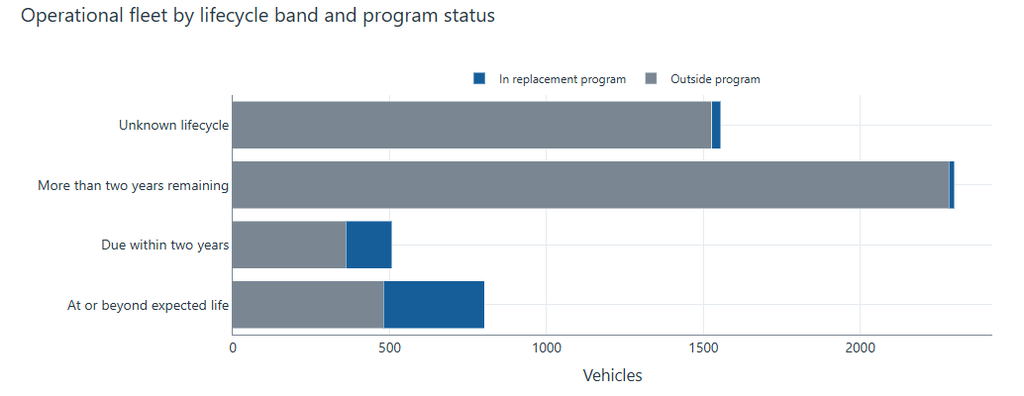

Verified reconciliation

| Metric | Numerator | Eligible | Share | Excluded | Coverage |
| --- | --- | --- | --- | --- | --- |
| Fleet vehicles | 5,610 | 5,610 | 100.0% | 0 | 100.0% |
| Operational vehicles | 5,166 | 5,610 | 92.1% | 0 | 100.0% |
| In replacement program | 514 | 5,166 | 9.9% | 444 | 92.1% |
| Operational lifecycle urgent | 1,310 | 3,610 | 36.3% | 1,556 | 69.9% |
| Lifecycle urgent outside program | 842 | 3,610 | 23.3% | 1,556 | 69.9% |

[figure not shown]

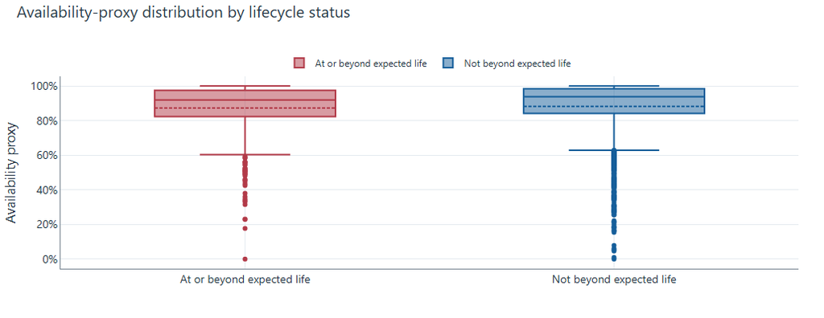

What this answers

The replacement-program flag is an observed management decision, not ground truth. H2 tests whether that decision is associated with lifecycle urgency. Current-program vehicles remain in this audit but never enter the new-candidate queue.

Decision boundary

This snapshot can show alignment and exceptions. It cannot prove causation or that any specific vehicle must be replaced. Condition inspection, safety, work-order and cost evidence remain necessary for approval.

Reliability investigation

Low-availability vehicles that do not meet the complete lifecycle-and-peer replacement rule.

| Unit ID | Division | Unit Type | Lifecycle Band | Availability Proxy | Availability Peer Percentile | Review Tier | Reason Codes |
| --- | --- | --- | --- | --- | --- | --- | --- |
| 319217 | TRANSPORTATION SERVICES | OFF-ROAD | More than two years remaining | 77.1% | 51.3% | Planning | OUTSIDE_REPLACEMENT_PROGRAM\|LOW_AVAILABILITY_PROXY |
| 319235 | TRANSPORTATION SERVICES | OFF-ROAD | More than two years remaining | 62.7% | 34.2% | Planning | OUTSIDE_REPLACEMENT_PROGRAM\|LOW_AVAILABILITY_PROXY |
| 319244 | PARKS, FORESTRY & RECREATION | OFF-ROAD | More than two years remaining | 76.6% | 12.5% | Planning | OUTSIDE_REPLACEMENT_PROGRAM\|LOW_AVAILABILITY_PROXY\|BOTTOM_PEER_QUINTILE |
| 041424 | PARKS, FORESTRY & RECREATION | LIGHT DUTY | More than two years remaining | 76.1% | 3.6% | High | OUTSIDE_REPLACEMENT_PROGRAM\|LOW_AVAILABILITY_PROXY\|BOTTOM_PEER_QUINTILE\|BOTTOM_PEER_DECILE |
| 046028 | TORONTO WATER | LIGHT DUTY | More than two years remaining | 72.9% | 5.1% | High | OUTSIDE_REPLACEMENT_PROGRAM\|LOW_AVAILABILITY_PROXY\|BOTTOM_PEER_QUINTILE\|BOTTOM_PEER_DECILE |
| 063096 | SOLID WASTE MANAGEMENT | LIGHT DUTY | More than two years remaining | 78.4% | 33.3% | Planning | OUTSIDE_REPLACEMENT_PROGRAM\|LOW_AVAILABILITY_PROXY |
| 065158 | SOLID WASTE MANAGEMENT | LIGHT DUTY | More than two years remaining | 57.5% | 2.7% | High | OUTSIDE_REPLACEMENT_PROGRAM\|LOW_AVAILABILITY_PROXY\|SEVERE_AVAILABILITY_PROXY\|BOTTOM_PEER_QUINTILE\|BOTTOM_PEER_DECILE |
| 067067 | TRANSPORTATION SERVICES | LIGHT DUTY | More than two years remaining | 39.1% | 1.0% | High | OUTSIDE_REPLACEMENT_PROGRAM\|LOW_AVAILABILITY_PROXY\|SEVERE_AVAILABILITY_PROXY\|BOTTOM_PEER_QUINTILE\|BOTTOM_PEER_DECILE |
| 075007 | TRANSPORTATION SERVICES | MEDIUM DUTY | More than two years remaining | 46.7% | 2.1% | High | OUTSIDE_REPLACEMENT_PROGRAM\|LOW_AVAILABILITY_PROXY\|SEVERE_AVAILABILITY_PROXY\|BOTTOM_PEER_QUINTILE\|BOTTOM_PEER_DECILE |
| 076060 | PARKS, FORESTRY & RECREATION | MEDIUM DUTY | More than two years remaining | 73.8% | 9.6% | High | OUTSIDE_REPLACEMENT_PROGRAM\|LOW_AVAILABILITY_PROXY\|BOTTOM_PEER_QUINTILE\|BOTTOM_PEER_DECILE |
| 112382 | MUNICIPAL LICENSING & STDS | LIGHT DUTY | More than two years remaining | 74.8% | 6.7% | High | OUTSIDE_REPLACEMENT_PROGRAM\|LOW_AVAILABILITY_PROXY\|BOTTOM_PEER_QUINTILE\|BOTTOM_PEER_DECILE |
| 112515 | ENGINEERING & CONSTR. SERVICES | LIGHT DUTY | More than two years remaining | 51.6% | 2.0% | High | OUTSIDE_REPLACEMENT_PROGRAM\|LOW_AVAILABILITY_PROXY\|SEVERE_AVAILABILITY_PROXY\|BOTTOM_PEER_QUINTILE\|BOTTOM_PEER_DECILE |
| 112542 | ENGINEERING & CONSTR. SERVICES | LIGHT DUTY | More than two years remaining | 77.9% | 8.6% | High | OUTSIDE_REPLACEMENT_PROGRAM\|LOW_AVAILABILITY_PROXY\|BOTTOM_PEER_QUINTILE\|BOTTOM_PEER_DECILE |
| 156182 | TRANSPORTATION SERVICES | MEDIUM DUTY | More than two years remaining | 55.5% | 3.1% | High | OUTSIDE_REPLACEMENT_PROGRAM\|LOW_AVAILABILITY_PROXY\|SEVERE_AVAILABILITY_PROXY\|BOTTOM_PEER_QUINTILE\|BOTTOM_PEER_DECILE |
| 188040 | TORONTO WATER | HEAVY DUTY | More than two years remaining | 76.2% | 19.1% | High | OUTSIDE_REPLACEMENT_PROGRAM\|LOW_AVAILABILITY_PROXY\|BOTTOM_PEER_QUINTILE\|HIGH_PRIORITY_SERVICE |
| 191014 | TRANSPORTATION SERVICES | HEAVY DUTY | More than two years remaining | 61.3% | 10.9% | Planning | OUTSIDE_REPLACEMENT_PROGRAM\|LOW_AVAILABILITY_PROXY\|BOTTOM_PEER_QUINTILE |
| 194013 | TORONTO WATER | HEAVY DUTY | More than two years remaining | 59.2% | 9.0% | High | OUTSIDE_REPLACEMENT_PROGRAM\|LOW_AVAILABILITY_PROXY\|SEVERE_AVAILABILITY_PROXY\|BOTTOM_PEER_QUINTILE\|BOTTOM_PEER_DECILE |
| 204038 | TORONTO WATER | HEAVY DUTY | More than two years remaining | 67.1% | 16.7% | Planning | OUTSIDE_REPLACEMENT_PROGRAM\|LOW_AVAILABILITY_PROXY\|BOTTOM_PEER_QUINTILE |
| 205028 | SOLID WASTE MANAGEMENT | HEAVY DUTY | More than two years remaining | 77.2% | 30.3% | Planning | OUTSIDE_REPLACEMENT_PROGRAM\|LOW_AVAILABILITY_PROXY |
| 222035 | SOLID WASTE MANAGEMENT | MEDIUM DUTY | More than two years remaining | 67.6% | 28.6% | Planning | OUTSIDE_REPLACEMENT_PROGRAM\|LOW_AVAILABILITY_PROXY |
| 315094 | TRANSPORTATION SERVICES | HEAVY DUTY | More than two years remaining | 38.3% | 37.8% | High | OUTSIDE_REPLACEMENT_PROGRAM\|LOW_AVAILABILITY_PROXY\|SEVERE_AVAILABILITY_PROXY |
| 315109 | TRANSPORTATION SERVICES | HEAVY DUTY | More than two years remaining | 27.6% | 21.6% | High | OUTSIDE_REPLACEMENT_PROGRAM\|LOW_AVAILABILITY_PROXY\|SEVERE_AVAILABILITY_PROXY |
| 319206 | TRANSPORTATION SERVICES | OFF-ROAD | More than two years remaining | 74.3% | 48.7% | Planning | OUTSIDE_REPLACEMENT_PROGRAM\|LOW_AVAILABILITY_PROXY |
| 319220 | TRANSPORTATION SERVICES | OFF-ROAD | More than two years remaining | 38.6% | 10.5% | High | OUTSIDE_REPLACEMENT_PROGRAM\|LOW_AVAILABILITY_PROXY\|SEVERE_AVAILABILITY_PROXY\|BOTTOM_PEER_QUINTILE |
| 323109 | TRANSPORTATION SERVICES | OFF-ROAD | More than two years remaining | 61.0% | 3.5% | High | OUTSIDE_REPLACEMENT_PROGRAM\|LOW_AVAILABILITY_PROXY\|BOTTOM_PEER_QUINTILE\|BOTTOM_PEER_DECILE |
| 323114 | SOLID WASTE MANAGEMENT | OFF-ROAD | More than two years remaining | 75.0% | 25.0% | Planning | OUTSIDE_REPLACEMENT_PROGRAM\|LOW_AVAILABILITY_PROXY |
| 330170 | SOLID WASTE MANAGEMENT | OFF-ROAD | Due within two years | 69.8% | 22.0% | Planning | OUTSIDE_REPLACEMENT_PROGRAM\|DUE_WITHIN_TWO_YEARS\|LOW_AVAILABILITY_PROXY |
| 333026 | SOLID WASTE MANAGEMENT | OFF-ROAD | More than two years remaining | 69.7% | 8.0% | High | OUTSIDE_REPLACEMENT_PROGRAM\|LOW_AVAILABILITY_PROXY\|BOTTOM_PEER_QUINTILE\|BOTTOM_PEER_DECILE |
| 041419 | FACILITIES MGMT & REAL ESTATE | LIGHT DUTY | More than two years remaining | 64.6% | 1.2% | High | OUTSIDE_REPLACEMENT_PROGRAM\|LOW_AVAILABILITY_PROXY\|BOTTOM_PEER_QUINTILE\|BOTTOM_PEER_DECILE |
| 045206 | PARKS, FORESTRY & RECREATION | LIGHT DUTY | More than two years remaining | 77.5% | 8.4% | High | OUTSIDE_REPLACEMENT_PROGRAM\|LOW_AVAILABILITY_PROXY\|BOTTOM_PEER_QUINTILE\|BOTTOM_PEER_DECILE |
| 051023 | SOLID WASTE MANAGEMENT | LIGHT DUTY | More than two years remaining | 78.1% | 29.6% | Planning | OUTSIDE_REPLACEMENT_PROGRAM\|LOW_AVAILABILITY_PROXY |
| 065133 | TRANSPORTATION SERVICES | LIGHT DUTY | More than two years remaining | 31.1% | 0.5% | High | OUTSIDE_REPLACEMENT_PROGRAM\|LOW_AVAILABILITY_PROXY\|SEVERE_AVAILABILITY_PROXY\|BOTTOM_PEER_QUINTILE\|BOTTOM_PEER_DECILE |
| 067130 | SOLID WASTE MANAGEMENT | LIGHT DUTY | More than two years remaining | 73.4% | 5.6% | High | OUTSIDE_REPLACEMENT_PROGRAM\|LOW_AVAILABILITY_PROXY\|BOTTOM_PEER_QUINTILE\|BOTTOM_PEER_DECILE |
| 076092 | PARKS, FORESTRY & RECREATION | MEDIUM DUTY | More than two years remaining | 78.3% | 16.0% | Planning | OUTSIDE_REPLACEMENT_PROGRAM\|LOW_AVAILABILITY_PROXY\|BOTTOM_PEER_QUINTILE |
| 112402 | PARKS, FORESTRY & RECREATION | LIGHT DUTY | More than two years remaining | 78.7% | 9.2% | High | OUTSIDE_REPLACEMENT_PROGRAM\|LOW_AVAILABILITY_PROXY\|BOTTOM_PEER_QUINTILE\|BOTTOM_PEER_DECILE |
| 156168 | PARKS, FORESTRY & RECREATION | MEDIUM DUTY | More than two years remaining | 71.3% | 8.5% | High | OUTSIDE_REPLACEMENT_PROGRAM\|LOW_AVAILABILITY_PROXY\|BOTTOM_PEER_QUINTILE\|BOTTOM_PEER_DECILE |
| 156197 | TRANSPORTATION SERVICES | MEDIUM DUTY | More than two years remaining | 79.4% | 17.6% | Planning | OUTSIDE_REPLACEMENT_PROGRAM\|LOW_AVAILABILITY_PROXY\|BOTTOM_PEER_QUINTILE |
| 187031 | TRANSPORTATION SERVICES | HEAVY DUTY | More than two years remaining | 55.5% | 6.3% | High | OUTSIDE_REPLACEMENT_PROGRAM\|LOW_AVAILABILITY_PROXY\|SEVERE_AVAILABILITY_PROXY\|BOTTOM_PEER_QUINTILE\|BOTTOM_PEER_DECILE |
| 204021 | TORONTO WATER | MEDIUM DUTY | More than two years remaining | 58.8% | 10.2% | High | OUTSIDE_REPLACEMENT_PROGRAM\|LOW_AVAILABILITY_PROXY\|SEVERE_AVAILABILITY_PROXY\|BOTTOM_PEER_QUINTILE\|HIGH_PRIORITY_SERVICE |
| 204028 | SOLID WASTE MANAGEMENT | HEAVY DUTY | More than two years remaining | 79.7% | 36.2% | High | OUTSIDE_REPLACEMENT_PROGRAM\|LOW_AVAILABILITY_PROXY\|HIGH_PRIORITY_SERVICE |

Lifecycle planning

Overdue or due-soon vehicles retaining at least 80% high-confidence availability.

| Unit ID | Division | Unit Type | Lifecycle Band | Availability Proxy | Availability Peer Percentile | Review Tier | Reason Codes |
| --- | --- | --- | --- | --- | --- | --- | --- |
| 319106 | PARKS, FORESTRY & RECREATION | OFF-ROAD | At or beyond expected life | 99.7% | 87.0% | Planning | OUTSIDE_REPLACEMENT_PROGRAM\|AT_OR_BEYOND_EXPECTED_LIFE |
| 323070 | TRANSPORTATION SERVICES | OFF-ROAD | At or beyond expected life | 84.5% | 23.0% | Planning | OUTSIDE_REPLACEMENT_PROGRAM\|AT_OR_BEYOND_EXPECTED_LIFE\|HIGH_PRIORITY_SERVICE |
| 330171 | SOLID WASTE MANAGEMENT | OFF-ROAD | Due within two years | 92.6% | 87.8% | Planning | OUTSIDE_REPLACEMENT_PROGRAM\|DUE_WITHIN_TWO_YEARS |
| 330175 | SOLID WASTE MANAGEMENT | OFF-ROAD | Due within two years | 84.3% | 61.0% | Planning | OUTSIDE_REPLACEMENT_PROGRAM\|DUE_WITHIN_TWO_YEARS |
| 396371 | PARKS, FORESTRY & RECREATION | OFF-ROAD | Due within two years | 99.3% | 56.2% | Planning | OUTSIDE_REPLACEMENT_PROGRAM\|DUE_WITHIN_TWO_YEARS |
| 001075 | MUNICIPAL LICENSING & STDS | LIGHT DUTY | Due within two years | 98.5% | 64.0% | Planning | OUTSIDE_REPLACEMENT_PROGRAM\|DUE_WITHIN_TWO_YEARS |
| 001097 | MUNICIPAL LICENSING & STDS | LIGHT DUTY | Due within two years | 99.5% | 81.4% | Planning | OUTSIDE_REPLACEMENT_PROGRAM\|DUE_WITHIN_TWO_YEARS |
| 001098 | MUNICIPAL LICENSING & STDS | LIGHT DUTY | Due within two years | 95.7% | 35.5% | Planning | OUTSIDE_REPLACEMENT_PROGRAM\|DUE_WITHIN_TWO_YEARS |
| 005656 | FACILITIES MGMT & REAL ESTATE | OFF-ROAD | At or beyond expected life | 94.7% | 56.5% | Planning | OUTSIDE_REPLACEMENT_PROGRAM\|AT_OR_BEYOND_EXPECTED_LIFE |
| 007028 | TORONTO HOUSING COMPANY | LIGHT DUTY | Due within two years | 90.2% | 15.5% | Planning | OUTSIDE_REPLACEMENT_PROGRAM\|DUE_WITHIN_TWO_YEARS\|BOTTOM_PEER_QUINTILE |
| 041179 | TRANSPORTATION SERVICES | LIGHT DUTY | Due within two years | 95.4% | 33.8% | Planning | OUTSIDE_REPLACEMENT_PROGRAM\|DUE_WITHIN_TWO_YEARS |
| 044087 | PARKS, FORESTRY & RECREATION | LIGHT DUTY | Due within two years | 87.1% | 20.6% | Planning | OUTSIDE_REPLACEMENT_PROGRAM\|DUE_WITHIN_TWO_YEARS |
| 045100 | PARKS, FORESTRY & RECREATION | LIGHT DUTY | Due within two years | 84.7% | 16.9% | Planning | OUTSIDE_REPLACEMENT_PROGRAM\|DUE_WITHIN_TWO_YEARS\|BOTTOM_PEER_QUINTILE |
| 047031 | PARKS, FORESTRY & RECREATION | LIGHT DUTY | At or beyond expected life | 100.0% | 96.8% | Planning | OUTSIDE_REPLACEMENT_PROGRAM\|AT_OR_BEYOND_EXPECTED_LIFE |
| 050011 | SOLID WASTE MANAGEMENT | LIGHT DUTY | Due within two years | 93.9% | 41.2% | Planning | OUTSIDE_REPLACEMENT_PROGRAM\|DUE_WITHIN_TWO_YEARS |
| 061156 | PARKS, FORESTRY & RECREATION | LIGHT DUTY | At or beyond expected life | 99.4% | 83.0% | Planning | OUTSIDE_REPLACEMENT_PROGRAM\|AT_OR_BEYOND_EXPECTED_LIFE |
| 063082 | PARKS, FORESTRY & RECREATION | LIGHT DUTY | At or beyond expected life | 96.8% | 55.0% | Planning | OUTSIDE_REPLACEMENT_PROGRAM\|AT_OR_BEYOND_EXPECTED_LIFE |
| 065071 | FLEET SERVICES | LIGHT DUTY | At or beyond expected life | 96.5% | 53.2% | Planning | OUTSIDE_REPLACEMENT_PROGRAM\|AT_OR_BEYOND_EXPECTED_LIFE |
| 074016 | TRANSPORTATION SERVICES | MEDIUM DUTY | Due within two years | 99.3% | 95.1% | Planning | OUTSIDE_REPLACEMENT_PROGRAM\|DUE_WITHIN_TWO_YEARS |
| 076027 | PARKS, FORESTRY & RECREATION | MEDIUM DUTY | Due within two years | 99.5% | 96.1% | Planning | OUTSIDE_REPLACEMENT_PROGRAM\|DUE_WITHIN_TWO_YEARS |
| 077018 | PARKS, FORESTRY & RECREATION | MEDIUM DUTY | At or beyond expected life | 81.9% | 22.0% | Planning | OUTSIDE_REPLACEMENT_PROGRAM\|AT_OR_BEYOND_EXPECTED_LIFE |
| 094055 | FACILITIES MGMT & REAL ESTATE | LIGHT DUTY | At or beyond expected life | 91.6% | 20.3% | Planning | OUTSIDE_REPLACEMENT_PROGRAM\|AT_OR_BEYOND_EXPECTED_LIFE |
| 095127 | TORONTO HOUSING COMPANY | LIGHT DUTY | At or beyond expected life | 96.1% | 37.6% | Planning | OUTSIDE_REPLACEMENT_PROGRAM\|AT_OR_BEYOND_EXPECTED_LIFE |
| 095134 | MUNICIPAL LICENSING & STDS | LIGHT DUTY | Due within two years | 93.1% | 37.2% | Planning | OUTSIDE_REPLACEMENT_PROGRAM\|DUE_WITHIN_TWO_YEARS |
| 112337 | ENGINEERING & CONSTR. SERVICES | LIGHT DUTY | At or beyond expected life | 86.9% | 20.3% | Planning | OUTSIDE_REPLACEMENT_PROGRAM\|AT_OR_BEYOND_EXPECTED_LIFE |
| 112339 | ENGINEERING & CONSTR. SERVICES | LIGHT DUTY | At or beyond expected life | 95.9% | 50.9% | Planning | OUTSIDE_REPLACEMENT_PROGRAM\|AT_OR_BEYOND_EXPECTED_LIFE |
| 112347 | PUBLIC HEALTH | LIGHT DUTY | Due within two years | 84.8% | 17.3% | Planning | OUTSIDE_REPLACEMENT_PROGRAM\|DUE_WITHIN_TWO_YEARS\|BOTTOM_PEER_QUINTILE |
| 114032 | PARKS, FORESTRY & RECREATION | MEDIUM DUTY | Due within two years | 80.5% | 20.2% | Planning | OUTSIDE_REPLACEMENT_PROGRAM\|DUE_WITHIN_TWO_YEARS |
| 156115 | PARKS, FORESTRY & RECREATION | MEDIUM DUTY | At or beyond expected life | 85.0% | 27.6% | Planning | OUTSIDE_REPLACEMENT_PROGRAM\|AT_OR_BEYOND_EXPECTED_LIFE |
| 156153 | PARKS, FORESTRY & RECREATION | MEDIUM DUTY | Due within two years | 92.5% | 52.5% | Planning | OUTSIDE_REPLACEMENT_PROGRAM\|DUE_WITHIN_TWO_YEARS |
| 189015 | PARKS, FORESTRY & RECREATION | HEAVY DUTY | At or beyond expected life | 89.9% | 64.3% | Planning | OUTSIDE_REPLACEMENT_PROGRAM\|AT_OR_BEYOND_EXPECTED_LIFE\|HIGH_PRIORITY_SERVICE |
| 205013 | PARKS, FORESTRY & RECREATION | HEAVY DUTY | At or beyond expected life | 93.8% | 76.5% | Planning | OUTSIDE_REPLACEMENT_PROGRAM\|AT_OR_BEYOND_EXPECTED_LIFE\|HIGH_PRIORITY_SERVICE |
| 2166 | FACILITIES MGMT & REAL ESTATE | OFF-ROAD | At or beyond expected life | 97.9% | 58.6% | Planning | OUTSIDE_REPLACEMENT_PROGRAM\|AT_OR_BEYOND_EXPECTED_LIFE |
| 285061 | SOLID WASTE MANAGEMENT | OTHER | Due within two years | 86.1% | 13.9% | Planning | OUTSIDE_REPLACEMENT_PROGRAM\|DUE_WITHIN_TWO_YEARS\|BOTTOM_PEER_QUINTILE |
| 294053 | PARKS, FORESTRY & RECREATION | OTHER | Due within two years | 92.0% | 44.4% | Planning | OUTSIDE_REPLACEMENT_PROGRAM\|DUE_WITHIN_TWO_YEARS |
| 319120 | PARKS, FORESTRY & RECREATION | OFF-ROAD | At or beyond expected life | 98.1% | 72.5% | Planning | OUTSIDE_REPLACEMENT_PROGRAM\|AT_OR_BEYOND_EXPECTED_LIFE |
| 322075 | PARKS, FORESTRY & RECREATION | OFF-ROAD | Due within two years | 93.7% | 53.0% | Planning | OUTSIDE_REPLACEMENT_PROGRAM\|DUE_WITHIN_TWO_YEARS |
| 396345 | PARKS, FORESTRY & RECREATION | OFF-ROAD | At or beyond expected life | 98.2% | 42.2% | Planning | OUTSIDE_REPLACEMENT_PROGRAM\|AT_OR_BEYOND_EXPECTED_LIFE |
| 396366 | PARKS, FORESTRY & RECREATION | OFF-ROAD | Due within two years | 99.9% | 73.4% | Planning | OUTSIDE_REPLACEMENT_PROGRAM\|DUE_WITHIN_TWO_YEARS |
| 416005 | PARKS, FORESTRY & RECREATION | OTHER | Due within two years | 99.9% | 96.2% | Planning | OUTSIDE_REPLACEMENT_PROGRAM\|DUE_WITHIN_TWO_YEARS |

Data-quality review

Operational vehicles with incomplete lifecycle or insufficient availability confidence are routed here rather than assigned false precision.

| Unit ID | Division | Unit Type | Lifecycle Band | Availability Proxy | Availability Peer Percentile | Review Tier | Reason Codes |
| --- | --- | --- | --- | --- | --- | --- | --- |
| 319124 | PARKS, FORESTRY & RECREATION | OFF-ROAD | At or beyond expected life | 100.0% | — | Data review | OUTSIDE_REPLACEMENT_PROGRAM\|AT_OR_BEYOND_EXPECTED_LIFE\|INSUFFICIENT_PEER_GROUP\|SUSPECTED_SOURCE_DISPLACEMENT |
| 319148 | PARKS, FORESTRY & RECREATION | OFF-ROAD | Unknown lifecycle | 100.0% | 82.8% | Data review | OUTSIDE_REPLACEMENT_PROGRAM\|INVALID_LIFECYCLE_DATA |
| 319200 | TRANSPORTATION SERVICES | OFF-ROAD | Unknown lifecycle | — | — | Data review | OUTSIDE_REPLACEMENT_PROGRAM\|INSUFFICIENT_PEER_GROUP\|INVALID_LIFECYCLE_DATA\|INVALID_AVAILABILITY_DATA |
| 319240 | TORONTO WATER | OFF-ROAD | Unknown lifecycle | — | — | Data review | OUTSIDE_REPLACEMENT_PROGRAM\|INSUFFICIENT_PEER_GROUP\|INVALID_LIFECYCLE_DATA\|INVALID_AVAILABILITY_DATA\|SUSPECTED_SOURCE_DISPLACEMENT |
| 324023 | TORONTO WATER | OFF-ROAD | More than two years remaining | 99.7% | — | Data review | OUTSIDE_REPLACEMENT_PROGRAM\|INSUFFICIENT_PEER_GROUP\|SUSPECTED_SOURCE_DISPLACEMENT |
| 329034 | TORONTO WATER | OFF-ROAD | Unknown lifecycle | 99.5% | — | Data review | OUTSIDE_REPLACEMENT_PROGRAM\|INSUFFICIENT_PEER_GROUP\|INVALID_LIFECYCLE_DATA\|SUSPECTED_SOURCE_DISPLACEMENT |
| 329055 | SOLID WASTE MANAGEMENT | OFF-ROAD | Unknown lifecycle | — | — | Data review | OUTSIDE_REPLACEMENT_PROGRAM\|INSUFFICIENT_PEER_GROUP\|INVALID_LIFECYCLE_DATA\|INVALID_AVAILABILITY_DATA\|SUSPECTED_SOURCE_DISPLACEMENT |
| 329058 | EXHIBITION PLACE | OFF-ROAD | Unknown lifecycle | — | — | Data review | OUTSIDE_REPLACEMENT_PROGRAM\|INSUFFICIENT_PEER_GROUP\|INVALID_LIFECYCLE_DATA\|INVALID_AVAILABILITY_DATA\|SUSPECTED_SOURCE_DISPLACEMENT |
| 329066 | FLEET SERVICES | OFF-ROAD | Unknown lifecycle | — | — | Data review | OUTSIDE_REPLACEMENT_PROGRAM\|INSUFFICIENT_PEER_GROUP\|INVALID_LIFECYCLE_DATA\|INVALID_AVAILABILITY_DATA\|SUSPECTED_SOURCE_DISPLACEMENT |
| 330204 | SOLID WASTE MANAGEMENT | — | Unknown lifecycle | — | — | Data review | OUTSIDE_REPLACEMENT_PROGRAM\|INSUFFICIENT_PEER_GROUP\|INVALID_LIFECYCLE_DATA\|INVALID_AVAILABILITY_DATA\|SUSPECTED_SOURCE_DISPLACEMENT |
| 330217 | SOLID WASTE MANAGEMENT | OFF-ROAD | Unknown lifecycle | 97.6% | — | Data review | OUTSIDE_REPLACEMENT_PROGRAM\|INSUFFICIENT_PEER_GROUP\|INVALID_LIFECYCLE_DATA\|SUSPECTED_SOURCE_DISPLACEMENT |
| 376010 | PARKS, FORESTRY & RECREATION | OFF-ROAD | Unknown lifecycle | — | — | Data review | OUTSIDE_REPLACEMENT_PROGRAM\|INSUFFICIENT_PEER_GROUP\|INVALID_LIFECYCLE_DATA\|INVALID_AVAILABILITY_DATA\|SUSPECTED_SOURCE_DISPLACEMENT |
| 376023 | PARKS, FORESTRY & RECREATION | OFF-ROAD | Unknown lifecycle | — | — | Data review | OUTSIDE_REPLACEMENT_PROGRAM\|INSUFFICIENT_PEER_GROUP\|INVALID_LIFECYCLE_DATA\|INVALID_AVAILABILITY_DATA\|SUSPECTED_SOURCE_DISPLACEMENT |
| 376045 | ARENA BOARDS OF MGMT | OFF-ROAD | Unknown lifecycle | — | — | Data review | OUTSIDE_REPLACEMENT_PROGRAM\|INSUFFICIENT_PEER_GROUP\|INVALID_LIFECYCLE_DATA\|INVALID_AVAILABILITY_DATA\|SUSPECTED_SOURCE_DISPLACEMENT |
| 376053 | ARENA BOARDS OF MGMT | OFF-ROAD | Unknown lifecycle | — | — | Data review | OUTSIDE_REPLACEMENT_PROGRAM\|INSUFFICIENT_PEER_GROUP\|INVALID_LIFECYCLE_DATA\|INVALID_AVAILABILITY_DATA\|SUSPECTED_SOURCE_DISPLACEMENT |
| 376061 | PARKS, FORESTRY & RECREATION | OFF-ROAD | Unknown lifecycle | — | — | Data review | OUTSIDE_REPLACEMENT_PROGRAM\|INSUFFICIENT_PEER_GROUP\|INVALID_LIFECYCLE_DATA\|INVALID_AVAILABILITY_DATA\|SUSPECTED_SOURCE_DISPLACEMENT |
| 376066 | PARKS, FORESTRY & RECREATION | OFF-ROAD | Unknown lifecycle | — | — | Data review | OUTSIDE_REPLACEMENT_PROGRAM\|INSUFFICIENT_PEER_GROUP\|INVALID_LIFECYCLE_DATA\|INVALID_AVAILABILITY_DATA\|SUSPECTED_SOURCE_DISPLACEMENT |
| 376074 | PARKS, FORESTRY & RECREATION | OFF-ROAD | Unknown lifecycle | — | — | Data review | OUTSIDE_REPLACEMENT_PROGRAM\|INSUFFICIENT_PEER_GROUP\|INVALID_LIFECYCLE_DATA\|INVALID_AVAILABILITY_DATA\|SUSPECTED_SOURCE_DISPLACEMENT |
| 376089 | PARKS, FORESTRY & RECREATION | OFF-ROAD | Unknown lifecycle | — | — | Data review | OUTSIDE_REPLACEMENT_PROGRAM\|INSUFFICIENT_PEER_GROUP\|INVALID_LIFECYCLE_DATA\|INVALID_AVAILABILITY_DATA\|SUSPECTED_SOURCE_DISPLACEMENT |
| 376115 | PARKS, FORESTRY & RECREATION | OFF-ROAD | Unknown lifecycle | — | — | Data review | OUTSIDE_REPLACEMENT_PROGRAM\|INSUFFICIENT_PEER_GROUP\|INVALID_LIFECYCLE_DATA\|INVALID_AVAILABILITY_DATA\|SUSPECTED_SOURCE_DISPLACEMENT |
| 376126 | ARENA BOARDS OF MGMT | OFF-ROAD | Unknown lifecycle | — | — | Data review | OUTSIDE_REPLACEMENT_PROGRAM\|INSUFFICIENT_PEER_GROUP\|INVALID_LIFECYCLE_DATA\|INVALID_AVAILABILITY_DATA\|SUSPECTED_SOURCE_DISPLACEMENT |
| 378105 | PARKS, FORESTRY & RECREATION | OFF-ROAD | Unknown lifecycle | — | — | Data review | OUTSIDE_REPLACEMENT_PROGRAM\|INSUFFICIENT_PEER_GROUP\|INVALID_LIFECYCLE_DATA\|INVALID_AVAILABILITY_DATA\|SUSPECTED_SOURCE_DISPLACEMENT |
| 378249 | PARKS, FORESTRY & RECREATION | OFF-ROAD | Due within two years | 99.9% | — | Data review | OUTSIDE_REPLACEMENT_PROGRAM\|DUE_WITHIN_TWO_YEARS\|INSUFFICIENT_PEER_GROUP\|SUSPECTED_SOURCE_DISPLACEMENT |
| 378258 | TORONTO WATER | OFF-ROAD | Unknown lifecycle | — | — | Data review | OUTSIDE_REPLACEMENT_PROGRAM\|INSUFFICIENT_PEER_GROUP\|INVALID_LIFECYCLE_DATA\|INVALID_AVAILABILITY_DATA\|SUSPECTED_SOURCE_DISPLACEMENT |
| 378261 | TORONTO WATER | OFF-ROAD | Unknown lifecycle | — | — | Data review | OUTSIDE_REPLACEMENT_PROGRAM\|INSUFFICIENT_PEER_GROUP\|INVALID_LIFECYCLE_DATA\|INVALID_AVAILABILITY_DATA\|SUSPECTED_SOURCE_DISPLACEMENT |
| 378268 | PARKS, FORESTRY & RECREATION | OFF-ROAD | Due within two years | 99.9% | — | Data review | OUTSIDE_REPLACEMENT_PROGRAM\|DUE_WITHIN_TWO_YEARS\|INSUFFICIENT_PEER_GROUP\|SUSPECTED_SOURCE_DISPLACEMENT |
| 378271 | TORONTO WATER | OFF-ROAD | Unknown lifecycle | — | — | Data review | OUTSIDE_REPLACEMENT_PROGRAM\|INSUFFICIENT_PEER_GROUP\|INVALID_LIFECYCLE_DATA\|INVALID_AVAILABILITY_DATA\|SUSPECTED_SOURCE_DISPLACEMENT |
| 378282 | PARKS, FORESTRY & RECREATION | OFF-ROAD | More than two years remaining | — | — | Data review | OUTSIDE_REPLACEMENT_PROGRAM\|INSUFFICIENT_PEER_GROUP\|INVALID_AVAILABILITY_DATA\|SUSPECTED_SOURCE_DISPLACEMENT |
| 378297 | TORONTO WATER | OFF-ROAD | Unknown lifecycle | — | — | Data review | OUTSIDE_REPLACEMENT_PROGRAM\|INSUFFICIENT_PEER_GROUP\|INVALID_LIFECYCLE_DATA\|INVALID_AVAILABILITY_DATA\|SUSPECTED_SOURCE_DISPLACEMENT |
| 378327 | PARKS, FORESTRY & RECREATION | OFF-ROAD | Unknown lifecycle | — | — | Data review | OUTSIDE_REPLACEMENT_PROGRAM\|INSUFFICIENT_PEER_GROUP\|INVALID_LIFECYCLE_DATA\|INVALID_AVAILABILITY_DATA\|SUSPECTED_SOURCE_DISPLACEMENT |
| 378328 | PARKS, FORESTRY & RECREATION | OFF-ROAD | Unknown lifecycle | — | — | Data review | OUTSIDE_REPLACEMENT_PROGRAM\|INSUFFICIENT_PEER_GROUP\|INVALID_LIFECYCLE_DATA\|INVALID_AVAILABILITY_DATA\|SUSPECTED_SOURCE_DISPLACEMENT |
| 378339 | PARKS, FORESTRY & RECREATION | OFF-ROAD | Unknown lifecycle | 62.8% | — | Data review | OUTSIDE_REPLACEMENT_PROGRAM\|LOW_AVAILABILITY_PROXY\|INSUFFICIENT_PEER_GROUP\|INVALID_LIFECYCLE_DATA\|SUSPECTED_SOURCE_DISPLACEMENT |
| 379051 | EXHIBITION PLACE | OFF-ROAD | Unknown lifecycle | — | — | Data review | OUTSIDE_REPLACEMENT_PROGRAM\|INSUFFICIENT_PEER_GROUP\|INVALID_LIFECYCLE_DATA\|INVALID_AVAILABILITY_DATA\|SUSPECTED_SOURCE_DISPLACEMENT |
| 379063 | EXHIBITION PLACE | OFF-ROAD | Unknown lifecycle | — | — | Data review | OUTSIDE_REPLACEMENT_PROGRAM\|INSUFFICIENT_PEER_GROUP\|INVALID_LIFECYCLE_DATA\|INVALID_AVAILABILITY_DATA\|SUSPECTED_SOURCE_DISPLACEMENT |
| 383002 | PARKS, FORESTRY & RECREATION | OFF-ROAD | More than two years remaining | — | — | Data review | OUTSIDE_REPLACEMENT_PROGRAM\|INSUFFICIENT_PEER_GROUP\|INVALID_AVAILABILITY_DATA |
| 384008 | MUNICIPAL LICENSING & STDS | OFF-ROAD | Unknown lifecycle | — | — | Data review | OUTSIDE_REPLACEMENT_PROGRAM\|INSUFFICIENT_PEER_GROUP\|INVALID_LIFECYCLE_DATA\|INVALID_AVAILABILITY_DATA\|SUSPECTED_SOURCE_DISPLACEMENT |
| 384009 | MUNICIPAL LICENSING & STDS | OFF-ROAD | Unknown lifecycle | — | — | Data review | OUTSIDE_REPLACEMENT_PROGRAM\|INSUFFICIENT_PEER_GROUP\|INVALID_LIFECYCLE_DATA\|INVALID_AVAILABILITY_DATA\|SUSPECTED_SOURCE_DISPLACEMENT |
| 396282 | PARKS, FORESTRY & RECREATION | OFF-ROAD | Unknown lifecycle | — | — | Data review | OUTSIDE_REPLACEMENT_PROGRAM\|INSUFFICIENT_PEER_GROUP\|INVALID_LIFECYCLE_DATA\|INVALID_AVAILABILITY_DATA\|SUSPECTED_SOURCE_DISPLACEMENT |
| 396307 | PARKS, FORESTRY & RECREATION | OFF-ROAD | At or beyond expected life | 100.0% | — | Data review | OUTSIDE_REPLACEMENT_PROGRAM\|AT_OR_BEYOND_EXPECTED_LIFE\|INSUFFICIENT_PEER_GROUP\|SUSPECTED_SOURCE_DISPLACEMENT |
| 396309 | PARKS, FORESTRY & RECREATION | OFF-ROAD | Unknown lifecycle | — | — | Data review | OUTSIDE_REPLACEMENT_PROGRAM\|INSUFFICIENT_PEER_GROUP\|INVALID_LIFECYCLE_DATA\|INVALID_AVAILABILITY_DATA\|SUSPECTED_SOURCE_DISPLACEMENT |

Sensitivity scenarios

| Availability Threshold | Peer Percentile Cutoff | Selected Vehicles |
| --- | --- | --- |
| 75.0% | 10.0% | 50 |
| 75.0% | 20.0% | 60 |
| 80.0% | 10.0% | 69 |
| 80.0% | 20.0% | 99 |
| 85.0% | 10.0% | 69 |
| 85.0% | 20.0% | 117 |

Stability is the share of six pre-specified absolute/peer threshold combinations under which a vehicle remains selected.

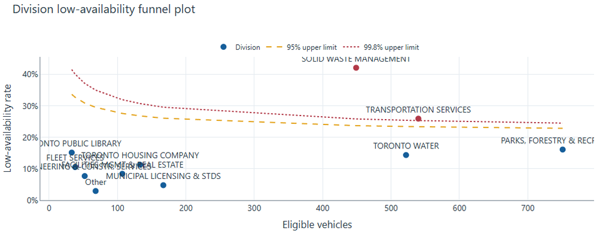

Interpretation

Raw counts are affected by fleet size. Funnel limits show expected variation. A hotspot label also requires a Benjamini–Hochberg-corrected p-value below 0.05. Adjusted marginal rates account for lifecycle band and unit type, but not unmeasured duty-cycle differences.

Division review summary

| Division | Operational Vehicles | Eligible Vehicles | Replacement Candidates | Actionable Outside Program | Low Availability Vehicles | Candidate Rate |
| --- | --- | --- | --- | --- | --- | --- |
| PARKS, FORESTRY & RECREATION | 1,641 | 705 | 54 | 1,219 | 132 | 7.7% |
| TRANSPORTATION SERVICES | 854 | 506 | 24 | 518 | 149 | 4.7% |
| SOLID WASTE MANAGEMENT | 678 | 250 | 7 | 295 | 212 | 2.8% |
| FACILITIES MGMT & REAL ESTATE | 142 | 97 | 6 | 74 | 9 | 6.2% |
| TORONTO WATER | 879 | 456 | 4 | 430 | 93 | 0.9% |
| MUNICIPAL LICENSING & STDS | 234 | 160 | 3 | 99 | 9 | 1.9% |
| TORONTO HOUSING COMPANY | 187 | 118 | 1 | 89 | 16 | 0.8% |
| ARENA BOARDS OF MGMT | 20 | 0 | 0 | 20 | 1 | — |
| FIRE SERVICES | 2 | 2 | 0 | 1 | 1 | 0.0% |
| FLEET SERVICES | 164 | 27 | 0 | 135 | 8 | 0.0% |
| INFORMATION & TECHNOLOGY | 3 | 2 | 0 | 1 | 0 | 0.0% |
| MAYORS OFFICE | 1 | 1 | 0 | 0 | 0 | 0.0% |
| OFFICE OF EMERGENCY | 2 | 1 | 0 | 2 | 0 | 0.0% |
| POLICY, PLANNING, FIN. & ADMIN | 1 | 1 | 0 | 0 | 0 | 0.0% |
| PUBLIC HEALTH | 10 | 8 | 0 | 6 | 0 | 0.0% |
| PURCHASING & MATERIALS MGMT | 17 | 7 | 0 | 13 | 1 | 0.0% |
| SHELTER, SUP., & HOUSING ADMIN | 13 | 10 | 0 | 5 | 1 | 0.0% |
| SHERBOURNE HEALTH CENTER | 2 | 0 | 0 | 2 | 0 | — |
| social services | 1 | 0 | 0 | 1 | 0 | — |
| ECO. DEVT. & CULTURE | 10 | 6 | 0 | 5 | 0 | 0.0% |

Maintenance-location review summary

| Maintenance Location | Operational Vehicles | Eligible Vehicles | Replacement Candidates | Actionable Outside Program | Low Availability Vehicles | Candidate Rate |
| --- | --- | --- | --- | --- | --- | --- |
| ELLESMERE GARAGE | 788 | 494 | 25 | 348 | 121 | 5.1% |
| INGRAM GARAGE | 272 | 205 | 18 | 149 | 58 | 8.8% |
| FINCH GARAGE | 744 | 471 | 16 | 355 | 74 | 3.4% |
| EASTERN GARAGE | 768 | 537 | 14 | 380 | 101 | 2.6% |
| DISCO GARAGE | 596 | 407 | 10 | 261 | 58 | 2.5% |
| BOOTH GARAGE | 258 | 171 | 10 | 121 | 58 | 5.8% |
| YONGE GARAGE | 104 | 69 | 5 | 47 | 29 | 7.2% |
| BERMONDSEY GARAGE | 123 | 34 | 1 | 22 | 67 | 2.9% |
| CFL038-18 | 1 | 0 | 0 | 1 | 0 | — |
| TS8030 | 1 | 0 | 0 | 1 | 0 | — |
| CONTRACT - EAST DISTRICT | 1 | 1 | 0 | 1 | 0 | 0.0% |
| CANADIAN NATIONAL EXHIBITION | 30 | 1 | 0 | 25 | 0 | 0.0% |
| DISCO TRANSFER STN | 5 | 3 | 0 | 3 | 4 | 0.0% |
| DUFFERIN TRANSFER STN | 7 | 6 | 0 | 2 | 2 | 0.0% |
| CFL038-17 | 1 | 0 | 0 | 1 | 0 | — |
| ECS650 | 1 | 0 | 0 | 1 | 0 | — |
| COMMISSIONERS ST TRANSFER STN | 2 | 0 | 0 | 1 | 1 | — |
| CFL017-24 | 2 | 0 | 0 | 2 | 0 | — |
| FL5004 | 1 | 0 | 0 | 1 | 0 | — |
| CFL010-26 | 1 | 0 | 0 | 1 | 0 | — |

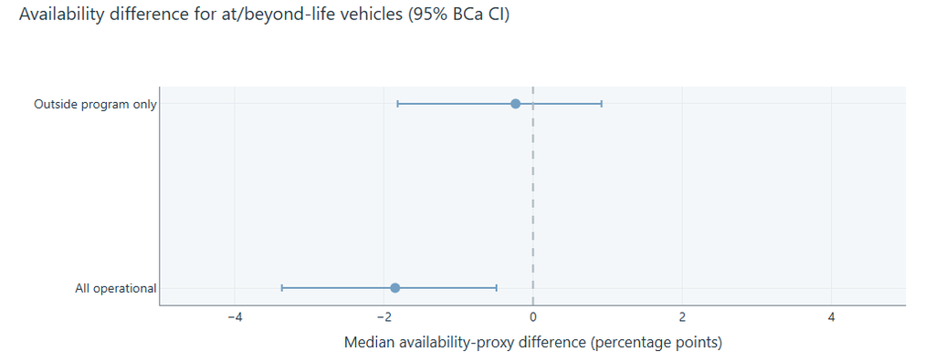

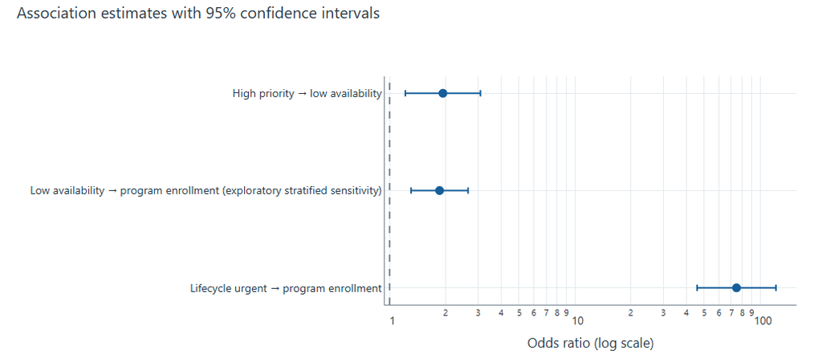

Fixed hypothesis results

Explorer filters do not recompute these predefined tests, preventing post-hoc significance hunting.

[output not shown]

Regression terms

| Hypothesis Id | Model Name | Covariance Type | Term | Coefficient | Standard Error | Adjusted Odds Ratio | 95% CI lower | 95% CI upper | P-value | Converged | Model n | Diagnostic Note |
| --- | --- | --- | --- | --- | --- | --- | --- | --- | --- | --- | --- | --- |
| H4 | Division-adjusted low-availability association | HC3 robust | Intercept | -0.71 | 0.54 | 0.49 | 0.17 | 1.42 | 0.1895 | Yes | 2,860 | Inference model; not evaluated as a classifier. |
| H4 | Division-adjusted low-availability association | HC3 robust | C(lifecycle_band)[T.Due within two years] | 0.41 | 0.17 | 1.50 | 1.08 | 2.09 | 0.01528 | Yes | 2,860 | Inference model; not evaluated as a classifier. |
| H4 | Division-adjusted low-availability association | HC3 robust | C(lifecycle_band)[T.More than two years remaining] | 0.00 | 0.14 | 1.00 | 0.76 | 1.32 | 0.9848 | Yes | 2,860 | Inference model; not evaluated as a classifier. |
| H4 | Division-adjusted low-availability association | HC3 robust | C(unit_type_group)[T.LIGHT DUTY] | -1.83 | 0.15 | 0.16 | 0.12 | 0.22 | 3.769e-33 | Yes | 2,860 | Inference model; not evaluated as a classifier. |
| H4 | Division-adjusted low-availability association | HC3 robust | C(unit_type_group)[T.MEDIUM DUTY] | -0.73 | 0.16 | 0.48 | 0.35 | 0.66 | 6.92e-06 | Yes | 2,860 | Inference model; not evaluated as a classifier. |
| H4 | Division-adjusted low-availability association | HC3 robust | C(unit_type_group)[T.OFF-ROAD] | -0.66 | 0.16 | 0.52 | 0.38 | 0.70 | 2.468e-05 | Yes | 2,860 | Inference model; not evaluated as a classifier. |
| H4 | Division-adjusted low-availability association | HC3 robust | C(unit_type_group)[T.OTHER] | -1.83 | 0.45 | 0.16 | 0.07 | 0.39 | 5.08e-05 | Yes | 2,860 | Inference model; not evaluated as a classifier. |
| H4 | Division-adjusted low-availability association | HC3 robust | C(division_group)[T.FACILITIES MGMT & REAL ESTATE] | -0.04 | 0.63 | 0.96 | 0.28 | 3.30 | 0.9454 | Yes | 2,860 | Inference model; not evaluated as a classifier. |
| H4 | Division-adjusted low-availability association | HC3 robust | C(division_group)[T.FLEET SERVICES] | -0.13 | 0.77 | 0.88 | 0.19 | 4.01 | 0.8691 | Yes | 2,860 | Inference model; not evaluated as a classifier. |
| H4 | Division-adjusted low-availability association | HC3 robust | C(division_group)[T.MUNICIPAL LICENSING & STDS] | -0.55 | 0.63 | 0.58 | 0.17 | 2.01 | 0.3882 | Yes | 2,860 | Inference model; not evaluated as a classifier. |
| H4 | Division-adjusted low-availability association | HC3 robust | C(division_group)[T.OTHER] | -1.28 | 0.91 | 0.28 | 0.05 | 1.64 | 0.1567 | Yes | 2,860 | Inference model; not evaluated as a classifier. |
| H4 | Division-adjusted low-availability association | HC3 robust | C(division_group)[T.PARKS, FORESTRY & RECREATION] | -0.10 | 0.55 | 0.90 | 0.31 | 2.64 | 0.8538 | Yes | 2,860 | Inference model; not evaluated as a classifier. |
| H4 | Division-adjusted low-availability association | HC3 robust | C(division_group)[T.SOLID WASTE MANAGEMENT] | 0.91 | 0.55 | 2.49 | 0.86 | 7.25 | 0.09431 | Yes | 2,860 | Inference model; not evaluated as a classifier. |
| H4 | Division-adjusted low-availability association | HC3 robust | C(division_group)[T.TORONTO HOUSING COMPANY] | 0.40 | 0.59 | 1.50 | 0.47 | 4.79 | 0.4965 | Yes | 2,860 | Inference model; not evaluated as a classifier. |
| H4 | Division-adjusted low-availability association | HC3 robust | C(division_group)[T.TORONTO PUBLIC LIBRARY] | -0.21 | 0.76 | 0.81 | 0.18 | 3.60 | 0.7808 | Yes | 2,860 | Inference model; not evaluated as a classifier. |
| H4 | Division-adjusted low-availability association | HC3 robust | C(division_group)[T.TORONTO WATER] | -0.12 | 0.55 | 0.88 | 0.30 | 2.60 | 0.8232 | Yes | 2,860 | Inference model; not evaluated as a classifier. |
| H4 | Division-adjusted low-availability association | HC3 robust | C(division_group)[T.TRANSPORTATION SERVICES] | 0.67 | 0.54 | 1.95 | 0.68 | 5.62 | 0.2176 | Yes | 2,860 | Inference model; not evaluated as a classifier. |

Concepts in plain language

- **Effect size:** how large a difference is, not merely whether it is detectable.
- **Confidence interval:** population effects compatible with the method and data.
- **P-value:** compatibility with a no-difference model, not the probability a conclusion is true.
- **BCa bootstrap:** a resampling interval adjusted for bias and asymmetry.
- **Cliff’s delta:** how often values in one group tend to exceed the other.
- **Adjusted odds ratio:** association after accounting for measured fleet mix.
- **FDR correction:** limits false discoveries across simultaneous hotspot tests.

Tests are two-sided at α=0.05 with complete cases, 10,000 deterministic permutations and 10,000 BCa resamples. Conclusions emphasize effect sizes and intervals before p-values.

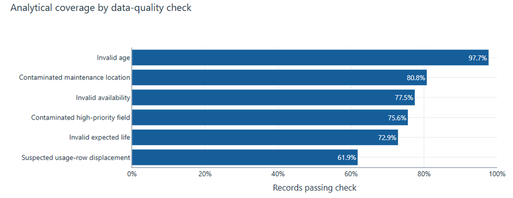

Field-level quality results

| Issue | Failed Records | Total Records | Coverage |
| --- | --- | --- | --- |
| Invalid availability | 1,263 | 5,610 | 77.5% |
| Suspected usage-row displacement | 2,140 | 5,610 | 61.9% |
| Contaminated maintenance location | 1,078 | 5,610 | 80.8% |
| Invalid age | 129 | 5,610 | 97.7% |
| Contaminated high-priority field | 1,369 | 5,610 | 75.6% |
| Invalid expected life | 1,520 | 5,610 | 72.9% |

Decision framework

Replacement-condition admission requires: operational and outside the program; valid lifecycle and high-confidence availability; at/beyond expected life or due within two years; availability below 80%; and bottom-20% peer availability.

Peers use unit type plus expected life at n≥30, fall back to unit type at n≥30, and otherwise receive no percentile. High priority only escalates a tier. Pareto fronts order candidates across lifecycle consumption, absolute availability and peer percentile.

Data-confidence controls

All source columns are ingested as text with hashes and row lineage. Typed fields never overwrite raw values. Exact duplicates are collapsed analytically; conflicting duplicate IDs are quarantined. Suspected displacement is never repaired speculatively.

Availability is explicitly a **proxy**. Usage, expected usage and VEU do not affect actions.

Availability-confidence robustness

The expanded definition recalculates peers after adding Medium-confidence availability. It is a robustness comparison only and does not change the primary High-confidence queue.

| Comparison | Selected Vehicles |
| --- | --- |
| Primary: High confidence | 99 |
| Expanded: High + Medium confidence | 99 |
| Selected under both definitions | 99 |
| Added only under expanded definition | 0 |
| Primary candidates not stable under expansion | 0 |

Proposed A/B test—not executed

- **Randomization:** maintenance garage.
- **Treatment:** shortlist plus structured condition-review checklist.
- **Control:** existing review process.
- **Primary outcome:** actionable intervention confirmed within 90 days.
- **Secondary outcomes:** inspection hours per finding, six-month downtime and emergency work orders.
- **Analysis:** intention-to-treat with garage-clustered standard errors.
- **Power:** pending a baseline rate and minimum worthwhile improvement.

Limitations and next data

This is a cross-sectional audit, not causal evidence or a replacement classifier. Savings are not estimated because repair and replacement costs are absent. Future work should add historical outcomes, work-order cost, failures, safety events and condition inspections.

Source: verified DuckDB analytical tables. Vehicle IDs are retained to support case-level review.